# DynAMoS Database

Dynamic Affective Movie Clip  
Database for Subjectivity Analysis

ACII 2023 | Girard, Tie, & Liebenthal  
https://dynamos.mgb.org

[figure not shown]

## Types of Emotion Ratings

- **Who is providing the measure of emotion?**
  - Self-reports of participants’ own emotion
  - Observer-perceptions of others’ emotion
- **How is emotion being represented?**
  - Discrete choices of emotion categories (e.g, happy, angry)
  - Continuous scores on emotion dimensions (e.g., valence)
- **How often are the emotions reported?**
  - Holistic ratings collected once after each stimulus
  - Dynamic ratings collected repeatedly during each stimulus

## Ambiguity and Subjectivity

- Emotion ratings will inevitably vary between raters…
- We usually treat such variability as a *nuisance* to “fix”
- But we can gain a lot by embracing these differences: studying their sources and building them into our models
- Ambiguity: variability across different *observers’ perceptions* of the emotion in a given stimulus (see [Sethu et al., 2019](https://arxiv.org/abs/1909.00360))
- Subjectivity: variability across different *subjects’ self-reports* of the emotion they experienced from a given stimulus

## DynAMoS Database

- **Participants**
  - Healthy community members from *Rally with MGB*
  - 83 participants (67% female, 18–59 years old)
  - 43 White, 22 Asian, 12 Black, 5 Other; 11 Hispanic/Latino
- **Procedure**
  - Watch 22 affective movie clips (2.2–7.1 minutes each)
  - Dynamic self-reported emotional valence ([CARMA](https://carma.jmgirard.com))
  - Holistic self-reported positive/negative affect (S-PANAS)

## Emotional Ratings

### Dynamic

–4 (*negative*) to +4 (*positive*)  
Rated at 30 Hz, binned to 1 Hz

[figure not shown]

### Holistic

Each rated 0 (*very slightly or not at all*) to 4 (*extremely*):

Positive Affect  
alert, determined, enthusiastic, excited, inspired

Negative Affect  
afraid, distressed, nervous, upset, scared

https://carma.jmgirard.com

## Quantifying Subjectivity

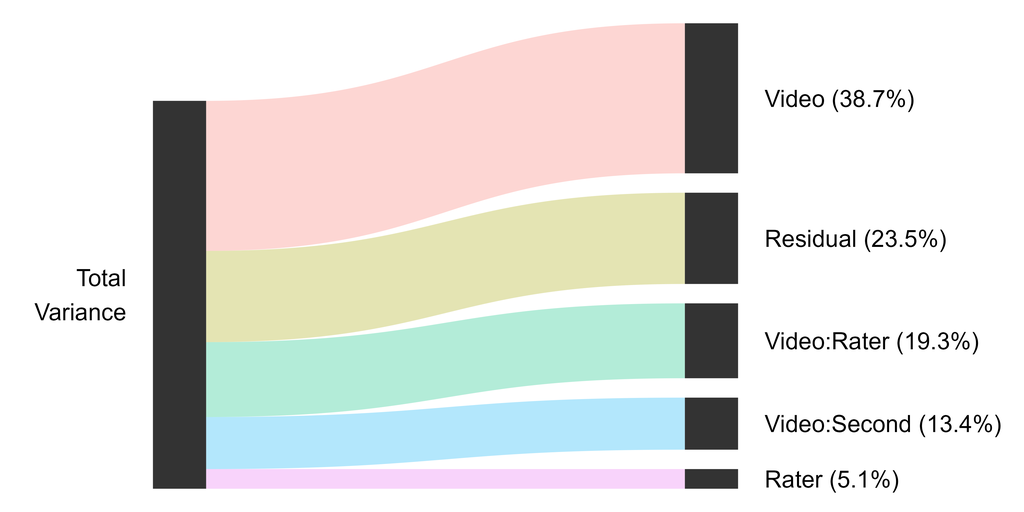

Estimates from a Bayesian G study (github.com/jmgirard/varde)

## Visualizing many time series is hard…

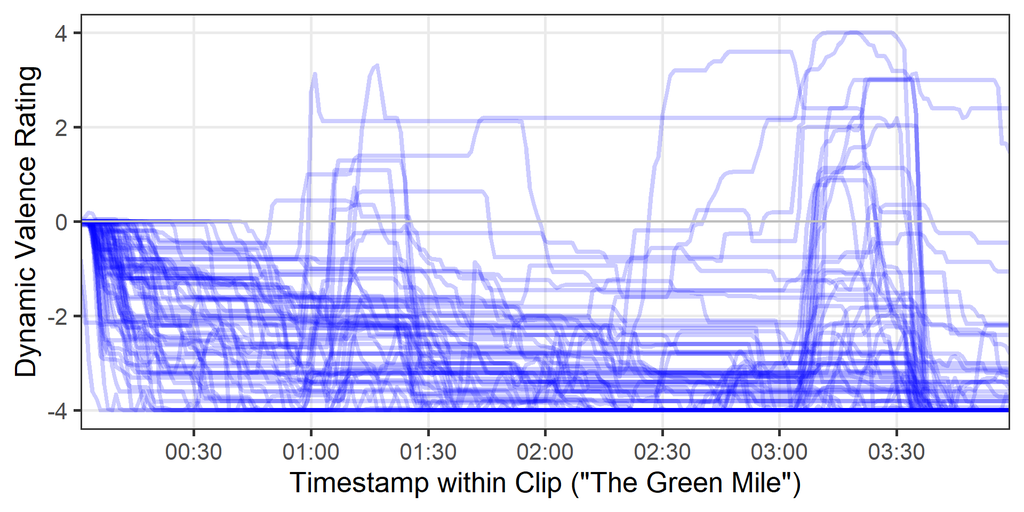

Each blue line is one participant’s time series

## Introducing the Chromodoris plot

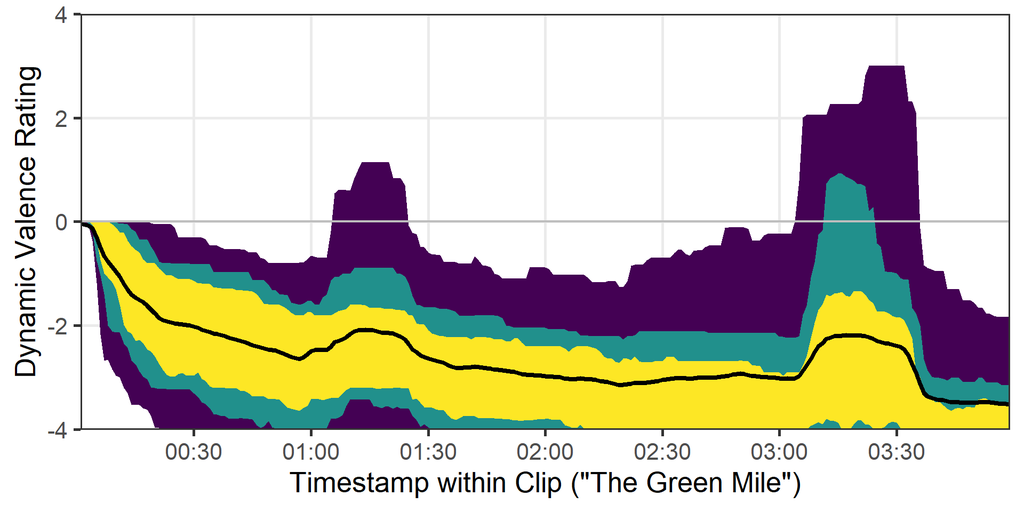

Black = Mean, Yellow = 50%, Green = 70%, Purple = 90%

## Database Uses

- **Emotion elicitation** video set with normative data
- Affective **content analysis** with average ratings
- Subjectivity analysis to predict **rating distributions**
- Subjectivity analysis to explain **degree of subjectivity**
- **Personalized modeling** of affective reactions

## Future Directions

1. Add more movie **clips** and **participants**
2. Add more dynamic and holistic rating **dimensions**
3. Add data from **sensors** (e.g., physiological and eye tracking)
4. Collect information about participants’ **personality**
5. Collect similar data in **clinical/medical** populations

## Acknowledgements

- **Co-authors**
  - Jeffrey Girard (University of Kansas)
  - Yanmei Tie (Brigham & Women’s Hospital, HMS)
  - Einat Liebenthal (McLean Hospital, HMS)
- **Funding**
  - Alexandra Golby (Brigham & Women’s Hospital, HMS)
- **Assistance**
  - Colin Gavin, Laura Rigolo, Abby Recko, Ben Phan

## Questions?

[figure not shown]

https://dynamos.mgb.org